# Comoto Cover

Malia Crane

8/24/2021

### Overview

This file holds a brief overview and narrative responses for the technical prompt.

Other files include:

> ComotoCraneDescriptives - A review of the dataset and its characteristics.

> ComotoCraneTemporal - An analysis first creating Non-refunded orders in the 90 day window, followed by the full time series analysis.

### Description of Sales Trends

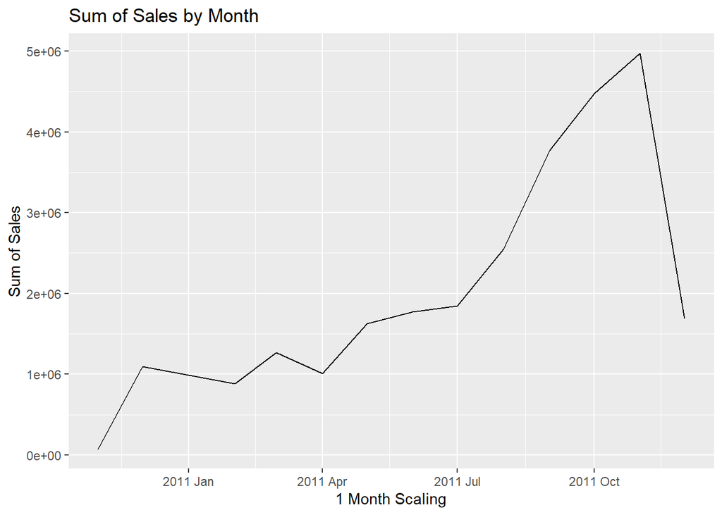

> Sales have been on an increasing volume during the period, with a marked increase between July and November 2011, ending with a dramatic decline during December 2011.

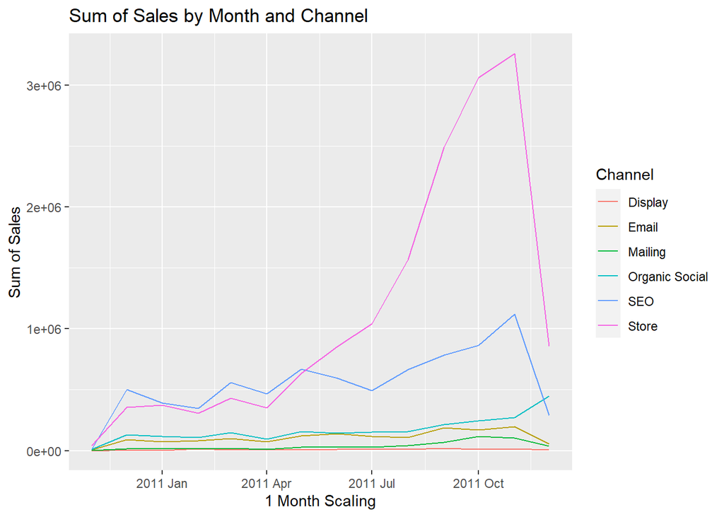

> This decline was experienced across all channels with the exception of Organic Social which saw an increase in sales. Forecasted sales estimates for the next 90 days show a gradual increase in sales to the prior year’s observations, strongest for the Store channel.

> Customer metrics provide additional insights, with a typical Sales Order having a median of $34.8 and a typical Customer purchase at $32.5. During the period at a total sales level, most customers have a median sales purchase total of $2.2k.

### Recommendations to Increase Sales

> 1: Store Channel is associated with the highest total sum of sale profits, but is also associated with the greatest crash seen in nearly all channels during Nov/Dec 2011. The most stable path forward is in understanding the cause of this drop and formenting a contingency plan. Although not a top contributor, Organic Social has steady growth and is the sole increasing channel during the crash period, suggesting development in this area may bolster resiliency against these types of crashes.